# harmony velociraptor dynamical_beige

## Get some stats on the unspliced counts

Sum = total counts and detected = the number of detected features calculating for the unspliced

```r
sce <- addPerCellQC(sce,
    subsets=list(Mito=grep("MT-", rownames(sce))),
    assay.type = "unspliced")
colData(sce)
```

```
## DataFrame with 7710 rows and 23 columns
##                               orig.ident nCount_RNA nFeature_RNA     sample
##                                 <factor>  <numeric>    <numeric>   <factor>
## asc.day0_AAACCTGAGATCGATA-1     asc_day0      33328         5355   asc_day0
## asc.day0_AAACCTGGTGTCAATC-1     asc_day0      31218         5537   asc_day0
## asc.day0_AAACCTGGTGTCTGAT-1     asc_day0      67188         7979   asc_day0
## asc.day0_AAACCTGGTTGGACCC-1     asc_day0      25445         4500   asc_day0
## asc.day0_AAACCTGTCGTGACAT-1     asc_day0      28359         4743   asc_day0
## ...                                  ...        ...          ...        ...
## beige.day3_TTTGTCAGTACAGTTC-1 beige_day3      24649         4132 beige_day3
## beige.day3_TTTGTCATCCGGGTGT-1 beige_day3      14129         3765 beige_day3
## beige.day3_TTTGTCATCCTGCAGG-1 beige_day3      18108         3678 beige_day3
## beige.day3_TTTGTCATCGCGTAGC-1 beige_day3      21075         4052 beige_day3
## beige.day3_TTTGTCATCGTACCGG-1 beige_day3      17331         3580 beige_day3
##                                 condition        time         rep percent.mt
##                               <character> <character> <character>  <numeric>
## asc.day0_AAACCTGAGATCGATA-1           asc        day0        rep1   0.366059
## asc.day0_AAACCTGGTGTCAATC-1           asc        day0        rep1   0.528541
## asc.day0_AAACCTGGTGTCTGAT-1           asc        day0        rep1   0.681669
## asc.day0_AAACCTGGTTGGACCC-1           asc        day0        rep1   0.396935
## asc.day0_AAACCTGTCGTGACAT-1           asc        day0        rep1   0.342043
## ...                                   ...         ...         ...        ...
## beige.day3_TTTGTCAGTACAGTTC-1       beige        day3        rep1    3.66749
## beige.day3_TTTGTCATCCGGGTGT-1       beige        day3        rep1    1.38014
## beige.day3_TTTGTCATCCTGCAGG-1       beige        day3        rep1    1.71195
## beige.day3_TTTGTCATCGCGTAGC-1       beige        day3        rep1    2.02610
## beige.day3_TTTGTCATCGTACCGG-1       beige        day3        rep1    1.63291
##                               RNA_snn_res.0.5 seurat_clusters  cond.time
##                                      <factor>        <factor>   <factor>
## asc.day0_AAACCTGAGATCGATA-1                 3               3   asc.day0
## asc.day0_AAACCTGGTGTCAATC-1                 3               3   asc.day0
## asc.day0_AAACCTGGTGTCTGAT-1                 8               8   asc.day0
## asc.day0_AAACCTGGTTGGACCC-1                 3               3   asc.day0
## asc.day0_AAACCTGTCGTGACAT-1                 3               3   asc.day0
## ...                                       ...             ...        ...
## beige.day3_TTTGTCAGTACAGTTC-1               1               1 beige.day3
## beige.day3_TTTGTCATCCGGGTGT-1               5               5 beige.day3
## beige.day3_TTTGTCATCCTGCAGG-1               1               1 beige.day3
## beige.day3_TTTGTCATCGCGTAGC-1               1               1 beige.day3
## beige.day3_TTTGTCATCGTACCGG-1               1               1 beige.day3
```

[output cut: 50 more lines]

```
## beige.day3_TTTGTCATCGCGTAGC-1                     0                    0
## beige.day3_TTTGTCATCGTACCGG-1                     0                    0
##                                   total
##                               <numeric>
## asc.day0_AAACCTGAGATCGATA-1        3675
## asc.day0_AAACCTGGTGTCAATC-1        4198
## asc.day0_AAACCTGGTGTCTGAT-1        9230
## asc.day0_AAACCTGGTTGGACCC-1        2263
## asc.day0_AAACCTGTCGTGACAT-1        3245
## ...                                 ...
## beige.day3_TTTGTCAGTACAGTTC-1      2803
## beige.day3_TTTGTCATCCGGGTGT-1      1721
## beige.day3_TTTGTCATCCTGCAGG-1      1842
## beige.day3_TTTGTCATCGCGTAGC-1      2487
## beige.day3_TTTGTCATCGTACCGG-1      1820
```

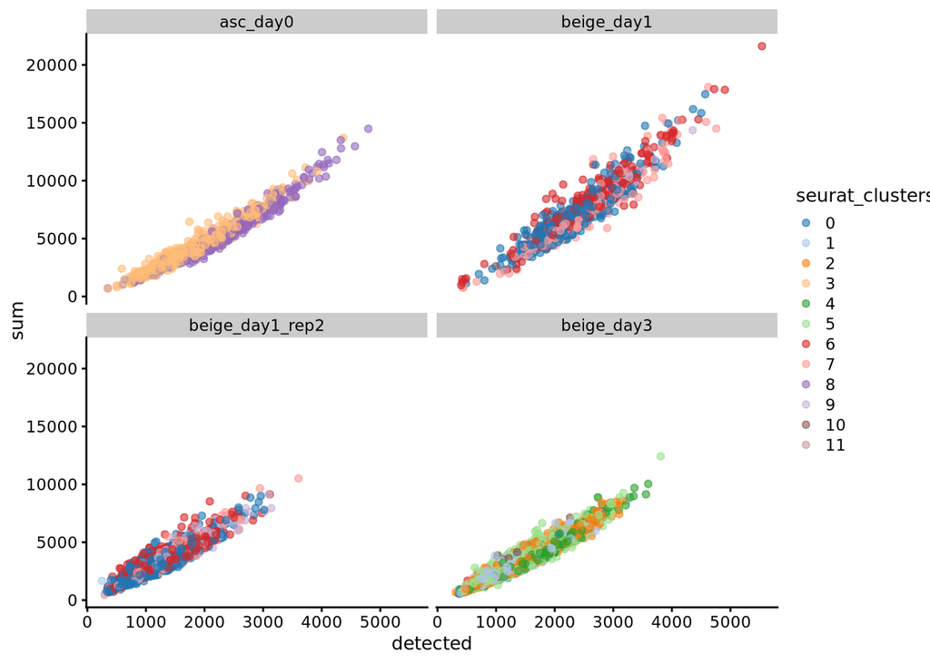

```r
plotColData(sce, y = "sum", x="detected", color_by="seurat_clusters", other_fields = "sample") + facet_wrap(~sample)
```

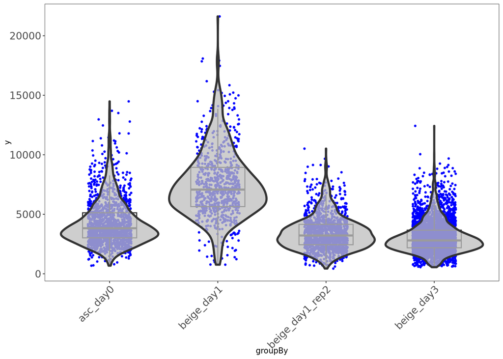

```r
singleCellTK::plotSCEViolin(sce, "colData", "sum", groupBy = "sample")
```

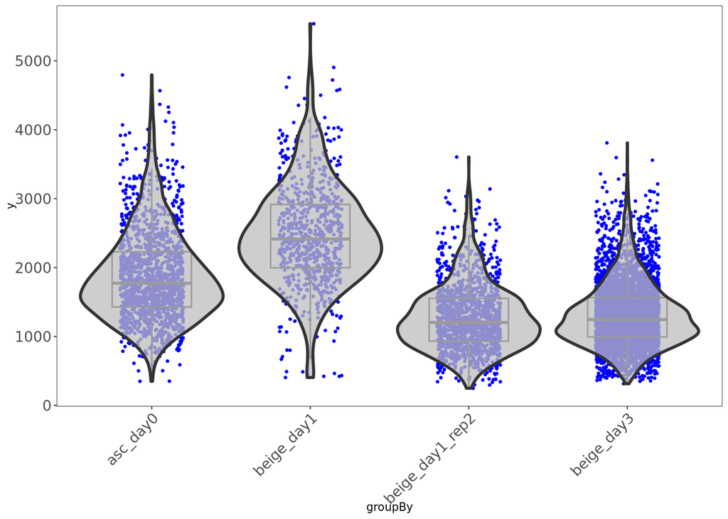

```r
singleCellTK::plotSCEViolin(sce, "colData", "detected", groupBy = "sample")
```

Okay interesting, the number of detected features drops for BOTH day1_rep2 and day3, even though day3 has been quantified in paired-end mode.

## Filter low expr genes

```r
nonzeroes = (assay(sce, "spliced") > 0 )* (assay(sce, "unspliced") > 0)
head(nonzeroes)
```

```
## <6 x 7710> matrix of class DelayedMatrix and type "integer":
##               asc.day0_AAACCTGAGATCGATA-1 ... beige.day3_TTTGTCATCGTACCGG-1
## MIR1302-2HG                             0   .                             0
## FAM138A                                 0   .                             0
## OR4F5                                   0   .                             0
## AL627309.1                              0   .                             0
## AL627309.3                              0   .                             0
## AL627309.2                              0   .                             0
```

```r
shared_counts = assay(sce, "spliced")*nonzeroes + assay(sce, "unspliced")*nonzeroes
head(shared_counts)
```

```
## <6 x 7710> matrix of class DelayedMatrix and type "integer":
##               asc.day0_AAACCTGAGATCGATA-1 ... beige.day3_TTTGTCATCGTACCGG-1
## MIR1302-2HG                             0   .                             0
## FAM138A                                 0   .                             0
## OR4F5                                   0   .                             0
## AL627309.1                              0   .                             0
## AL627309.3                              0   .                             0
## AL627309.2                              0   .                             0
```

```r
genes_to_keep = rowSums(shared_counts) > 20
summary(genes_to_keep)
```

```
##    Mode   FALSE    TRUE
## logical   25247   11354
```

```r
filt = sce[genes_to_keep,]
filt
```

```
## class: SingleCellExperiment
## dim: 11354 7710
## metadata(0):
## assays(5): counts logcounts scaledata unspliced spliced
## rownames(11354): LINC01409 LINC01128 ... AL592183.1 AC240274.1
## rowData names(0):
## colnames(7710): asc.day0_AAACCTGAGATCGATA-1 asc.day0_AAACCTGGTGTCAATC-1
##   ... beige.day3_TTTGTCATCGCGTAGC-1 beige.day3_TTTGTCATCGTACCGG-1
## colData names(23): orig.ident nCount_RNA ... subsets_Mito_percent total
## reducedDimNames(8): PCA UMAP ... UMAP.HARMONY TSNE.HARMONY
## mainExpName: RNA
## altExpNames(0):
```

```r
summary(variable.genes %in% rownames(filt))
```

```
##    Mode   FALSE    TRUE
## logical     575    1425
```

```r
variable.genes = variable.genes[variable.genes %in% rownames(filt)]
reducedDimNames(sce)
```

```
## [1] "PCA"          "UMAP"         "TSNE"         "INITIAL.UMAP" "INITIAL.TSNE"
## [6] "PCA.HARMONY"  "UMAP.HARMONY" "TSNE.HARMONY"
```

## Starting velocity analysis

Supplying variable genes and previously computed Integration reduction (acts as a PCA)

```r
velo.out = scvelo(sce, subset.row = variable.genes, use.dimred=red_name,
                  assay.X="counts", mode= model)
```

[output not shown]

```r
velo.out
```

```
## class: SingleCellExperiment
## dim: 1425 7710
## metadata(5): neighbors recover_dynamics velocity_params velocity_graph
##   velocity_graph_neg
## assays(10): X spliced ... velocity velocity_u
## rownames(1425): PLA2G2A MMP3 ... CACNB4 APCDD1L
## rowData names(18): fit_r2 fit_alpha ... velocity_genes varm
## colnames(7710): asc.day0_AAACCTGAGATCGATA-1 asc.day0_AAACCTGGTGTCAATC-1
##   ... beige.day3_TTTGTCATCGCGTAGC-1 beige.day3_TTTGTCATCGTACCGG-1
## colData names(8): velocity_self_transition root_cells ...
##   velocity_confidence velocity_confidence_transition
## reducedDimNames(1): X_pca
## mainExpName: NULL
## altExpNames(0):
```

```r
sce$velocity_pseudotime = velo.out$velocity_pseudotime
```

## pseuodtime

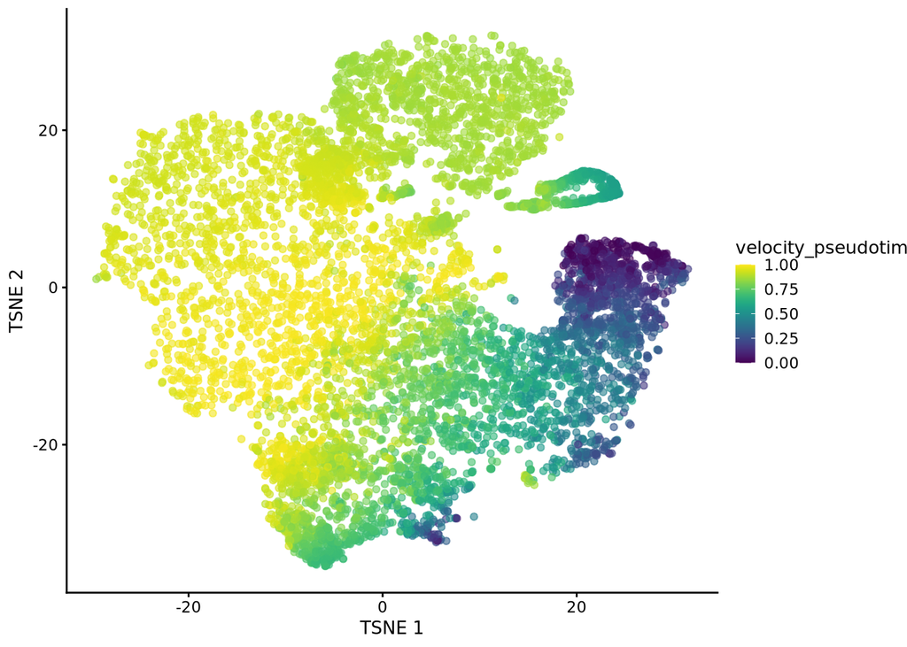

```r
plotTSNE(sce, color_by="velocity_pseudotime")
```

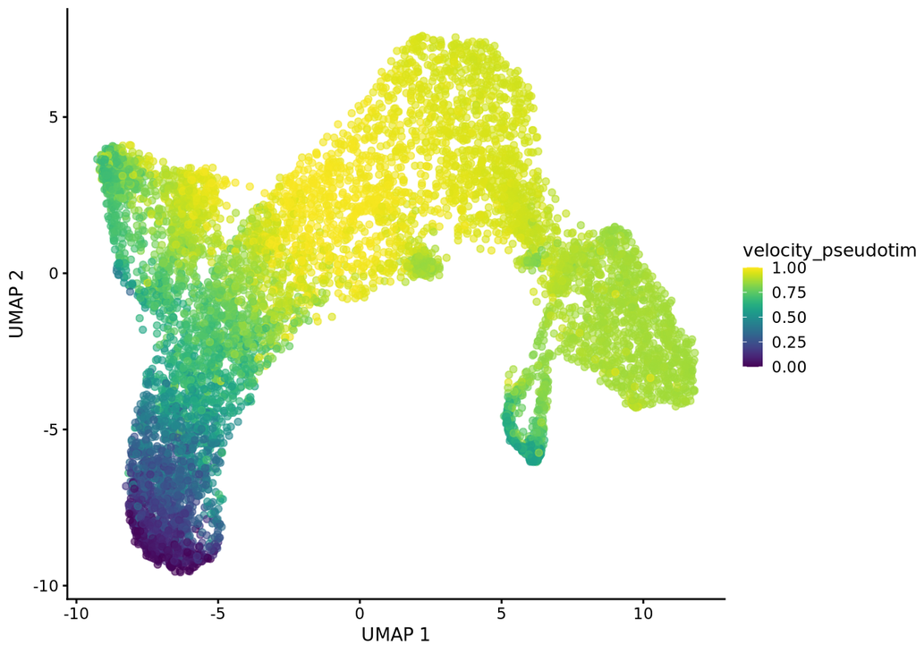

```r
plotUMAP(sce, color_by="velocity_pseudotime")
```

## Arrows on PCA

```r
embedded_pca <- embedVelocity(reducedDim(sce, red_name), velo.out)
```

```
## ℹ Using the 'X' assay as the X matrix
```

```
## computing velocity embedding
##     finished (0:00:03) --> added
##     'velocity_target', embedded velocity vectors (adata.obsm)
```

```r
dim(embedded_pca)
```

```
## [1] 7710   50
```

```r
reducedDim(sce, "PCA.SIMPLE") = reducedDim(sce, red_name)[,1:2]
grid.df <- gridVectors(sce, embedded_pca[,1:2], use.dimred = "PCA.SIMPLE")
colnames(grid.df) = gsub("harmony", "PC", colnames(grid.df))
head(grid.df)
```

```
##   start.PC_1 start.PC_2   end.PC_1   end.PC_2
## 1 -14.139443  -4.997718 -14.419679 -4.8604715
## 2 -15.346387  -5.850200 -15.783167 -5.7660727
## 3 -16.506349  -4.179298 -16.990413 -4.1234396
## 4 -15.276330  -4.195846 -15.876430 -4.1457629
## 5 -10.336046  -0.853240  -9.081809 -0.3834548
## 6  -9.386273  -4.126786  -9.104335 -3.8631720
```

```r
dim(grid.df)
```

```
## [1] 676   4
```

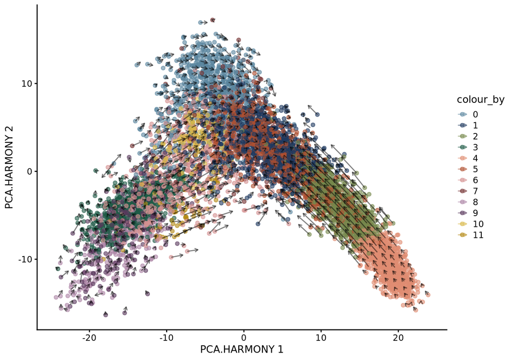

```r
plotReducedDim(sce, red_name,colour_by="initial_clusters") +
    geom_segment(data=grid.df, mapping=aes(x=start.PC_1, y=start.PC_2,
        xend=end.PC_1, yend=end.PC_2, colour=NULL), alpha=0.5,arrow=arrow(length=unit(0.05, "inches"))) &
  scale_colour_manual(values=clusters)
```

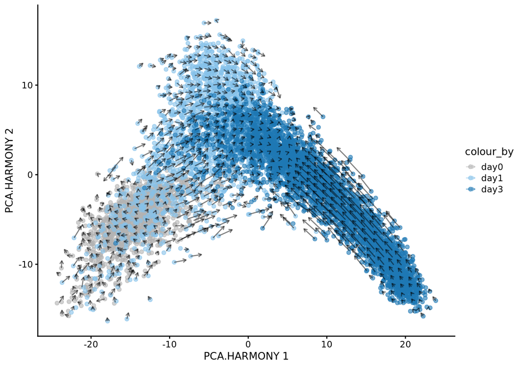

```r
plotReducedDim(sce, red_name,colour_by="time") +
    geom_segment(data=grid.df, mapping=aes(x=start.PC_1, y=start.PC_2,
        xend=end.PC_1, yend=end.PC_2, colour=NULL), alpha=0.5,arrow=arrow(length=unit(0.05, "inches"))) &
  scale_colour_manual(values=pal)
```

## Arrows on UMAP

```r
embedded <- embedVelocity(reducedDim(sce, "UMAP"), velo.out)
```

```
## ℹ Using the 'X' assay as the X matrix
```

```
## computing velocity embedding
##     finished (0:00:02) --> added
##     'velocity_target', embedded velocity vectors (adata.obsm)
```

```r
dim(embedded)
```

```
## [1] 7710    2
```

```r
grid.df <- gridVectors(sce, embedded, use.dimred = "UMAP", resolution=40)
head(grid.df)
```

```
##   start.umap_1 start.umap_2 end.umap_1 end.umap_2
## 1     8.962427   -0.3637243   9.309241 -0.3347752
## 2     9.459511   -2.5314014   9.491112 -2.2957279
## 3     5.315694   -4.1882897   5.274350 -4.3243581
## 4     8.862959    0.9641724   9.389643  0.9232371
## 5    10.454643   -0.7601226  10.588637 -0.7993466
## 6    10.945932   -2.0766215  11.103024 -2.2065889
```

```r
dim(grid.df)
```

```
## [1] 701   4
```

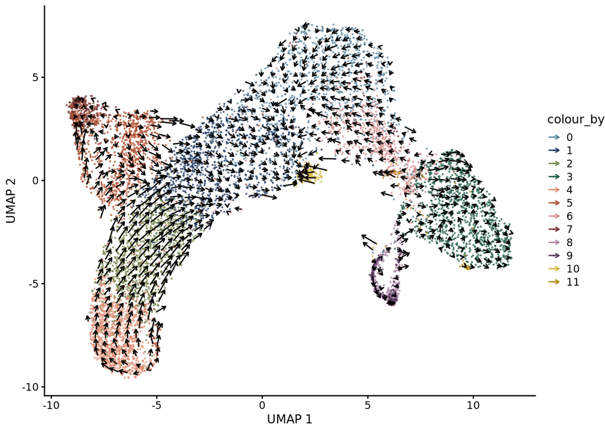

```r
if (subset_data){pt_size=1} else{pt_size=0.2}

plotReducedDim(sce, "UMAP",colour_by="initial_clusters", point_size=pt_size) +
    geom_segment(data=grid.df, mapping=aes(x=start.umap_1, y=start.umap_2,
        xend=end.umap_1, yend=end.umap_2, colour=NULL), width=1,arrow=arrow(length=unit(0.05, "inches"))) +
  scale_colour_manual(values=clusters)
```

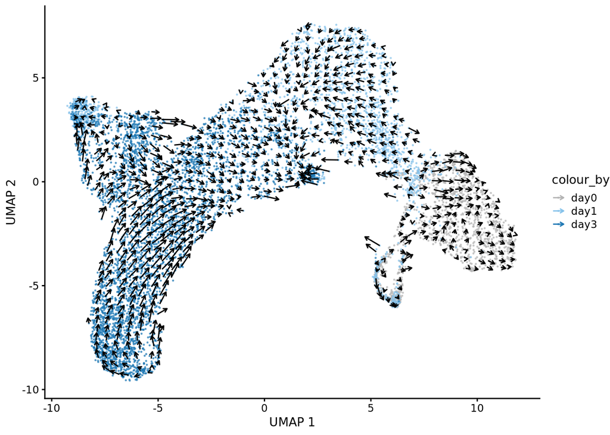

```r
plotReducedDim(sce, "UMAP",colour_by="time", point_size=pt_size) +
    geom_segment(data=grid.df, mapping=aes(x=start.umap_1, y=start.umap_2,
        xend=end.umap_1, yend=end.umap_2, colour=NULL), width=1,arrow=arrow(length=unit(0.05, "inches"))) +
  scale_colour_manual(values=pal)
```

## Arrows on tsne

```r
embedded <- embedVelocity(reducedDim(sce, "TSNE"), velo.out)
```

```
## ℹ Using the 'X' assay as the X matrix
```

```
## computing velocity embedding
##     finished (0:00:02) --> added
##     'velocity_target', embedded velocity vectors (adata.obsm)
```

```r
dim(embedded)
```

```
## [1] 7710    2
```

```r
grid.df <- gridVectors(sce, embedded, use.dimred = "TSNE", resolution=40)
head(grid.df)
```

```
##   start.tsne_1 start.tsne_2 end.tsne_1 end.tsne_2
## 1     4.996352     19.24321  5.3594729   20.09644
## 2     8.010715     19.04465  8.0089877   19.24428
## 3    18.236788     13.10442 17.9090151   12.84100
## 4    -1.654338     25.94912 -0.5458247   27.46660
## 5     7.791275     27.75352  7.4244002   27.95610
## 6    14.031134     26.42657 14.9932039   26.11003
```

```r
dim(grid.df)
```

```
## [1] 998   4
```

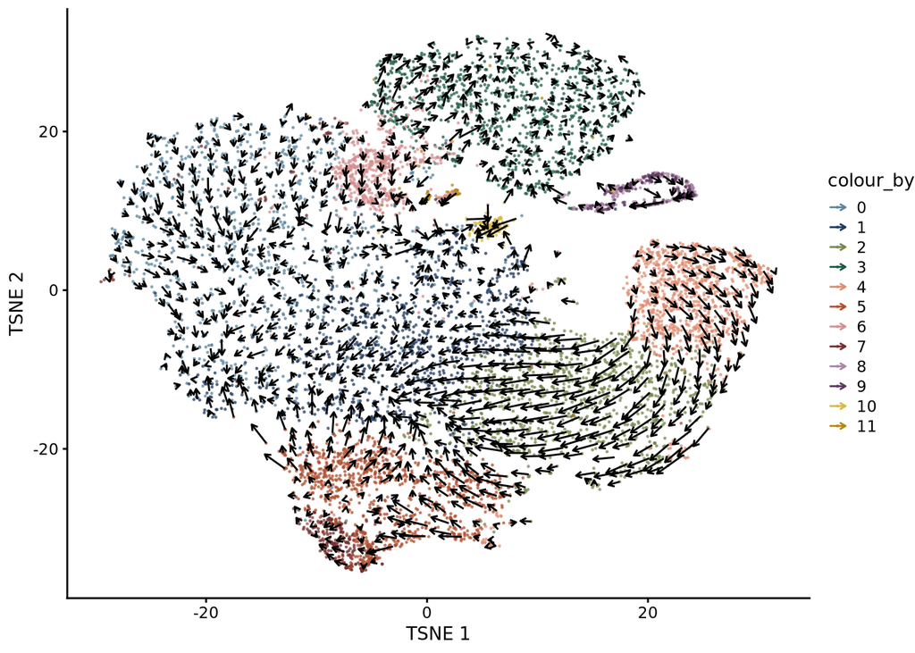

```r
if (subset_data){pt_size=1} else{pt_size=0.2}

plotReducedDim(sce, "TSNE",colour_by="initial_clusters", point_size=pt_size) +
    geom_segment(data=grid.df, mapping=aes(x=start.tsne_1, y=start.tsne_2,
        xend=end.tsne_1, yend=end.tsne_2, colour=NULL), width=1,arrow=arrow(length=unit(0.05, "inches"))) +
  scale_colour_manual(values=clusters)
```

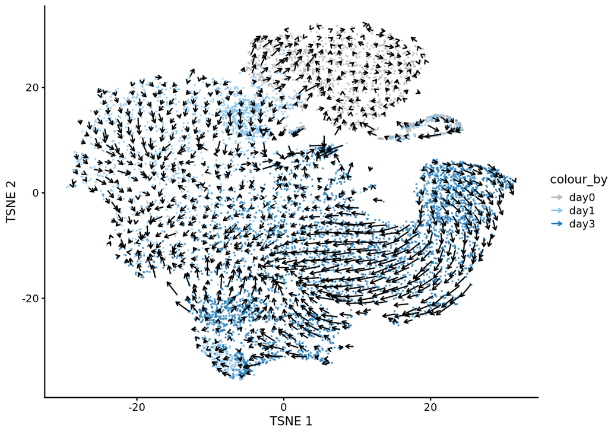

```r
plotReducedDim(sce,"TSNE",colour_by="time", point_size=pt_size) +
    geom_segment(data=grid.df, mapping=aes(x=start.tsne_1, y=start.tsne_2,
        xend=end.tsne_1, yend=end.tsne_2, colour=NULL), width=1,arrow=arrow(length=unit(0.05, "inches"))) +
  scale_colour_manual(values=pal)
```

### Add progenitor clusters

```r
pro_clusters = "/projects/imb-pkbphil/sp/sc_rnaseq/upr_in_adipo/output/progenitors/integration_trial_res0.3"
if (subset_data){
  filt = readRDS(here(pro_clusters, "10%_complete_analysis.rds"))
} else{
  filt = readRDS(here(pro_clusters, "complete_analysis.rds"))
}
filt
```

```
## An object of class Seurat
## 38601 features across 56638 samples within 2 assays
## Active assay: RNA (36601 features, 2000 variable features)
##  13 layers present: counts.S1, counts.S2, counts.S3, counts.S4, counts.S5, counts.S6, scale.data, data.S1, data.S2, data.S3, data.S4, data.S5, data.S6
##  1 other assay present: mnn.reconstructed
##  14 dimensional reductions calculated: pca, umap, tsne, initial.umap, initial.tsne, integrated.rpca, umap.rpca, rpca.tsne, integrated.harmony, umap.harmony, harmony.tsne, integrated.fastmnn, umap.fastmnn, fastmnn.tsne
```

```r
table(filt$rpca_clusters)
```

```
##
##     0     1     2     3     4     5     6     7
## 20853 16679  6851  5950  2382  2050   983   890
```

```r
head(filt$rpca_clusters)
```

```
## day0.subjectS1_AAACCTGAGACTAGAT-1 day0.subjectS1_AAACCTGAGCTGTCTA-1
##                                 2                                 1
## day0.subjectS1_AAACCTGAGTACGACG-1 day0.subjectS1_AAACCTGCAAACTGCT-1
##                                 1                                 1
## day0.subjectS1_AAACCTGCAAGGCTCC-1 day0.subjectS1_AAACCTGCACAAGTAA-1
##                                 2                                 2
## Levels: 0 1 2 3 4 5 6 7
```

```r
tail(filt$rpca_clusters)
```

```
## day0.subjectS6_TTTGTCAAGTACGCGA-1 day0.subjectS6_TTTGTCAAGTACGTAA-1
##                                 1                                 2
## day0.subjectS6_TTTGTCAAGTAGGCCA-1 day0.subjectS6_TTTGTCACACGGCCAT-1
##                                 5                                 3
## day0.subjectS6_TTTGTCATCACGGTTA-1 day0.subjectS6_TTTGTCATCCGCTGTT-1
##                                 3                                 0
## Levels: 0 1 2 3 4 5 6 7
```

```r
pro_clusters = filt$rpca_clusters
names(pro_clusters) = gsub("day0.subjectS6","asc.day0",names(pro_clusters))
head(pro_clusters[colnames(sce)])
```

```
## asc.day0_AAACCTGAGATCGATA-1 asc.day0_AAACCTGGTGTCAATC-1
##                           0                           0
## asc.day0_AAACCTGGTGTCTGAT-1 asc.day0_AAACCTGGTTGGACCC-1
##                           6                           0
## asc.day0_AAACCTGTCGTGACAT-1                        <NA>
##                           0                        <NA>
## Levels: 0 1 2 3 4 5 6 7
```

```r
sce$progen_clusters = pro_clusters[colnames(sce)]
table(sce$progen_clusters, useNA="ifany")
```

```
##
##    0    1    2    3    4    5    6    7 <NA>
##  448  312   80  102   26  224  159   92 6267
```

```r
sce$if_progen_cluster = paste0("w",sce$initial_clusters)
sce$if_progen_cluster[!is.na(sce$progen_clusters)] = paste0("p",sce$progen_clusters[!is.na(sce$progen_clusters)])
table(sce$if_progen_cluster, useNA="ifany")
```

```
##
##   p0   p1   p2   p3   p4   p5   p6   p7   w0   w1  w10   w2   w3   w4   w5   w6
##  448  312   80  102   26  224  159   92 1000 1000  133 1000    5 1000 1000  626
##   w7   w8   w9
##  327    7  169
```

```r
sce$time.progen_clusters = sce$time
sce$time.progen_clusters[!is.na(sce$progen_clusters)] = paste0("p",sce$progen_clusters[!is.na(sce$progen_clusters)])
table(sce$time.progen_clusters)
```

```
##
## day0 day1 day3   p0   p1   p2   p3   p4   p5   p6   p7
##   12 2154 4101  448  312   80  102   26  224  159   92
```

```r
rm(filt)
```

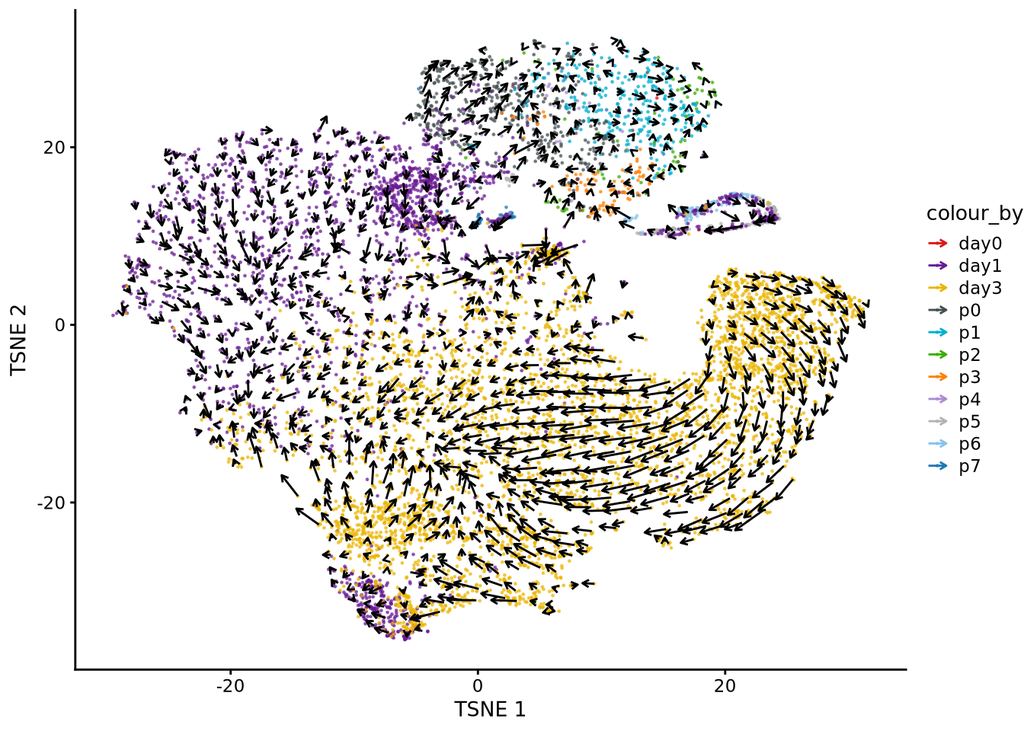

```r
plotReducedDim(sce, "TSNE",colour_by="time.progen_clusters", point_size=pt_size) +
    geom_segment(data=grid.df, mapping=aes(x=start.tsne_1, y=start.tsne_2,
        xend=end.tsne_1, yend=end.tsne_2, colour=NULL), width=1,arrow=arrow(length=unit(0.05, "inches"))) +
  scale_colour_manual(values=c(prog_cols, pal))
```

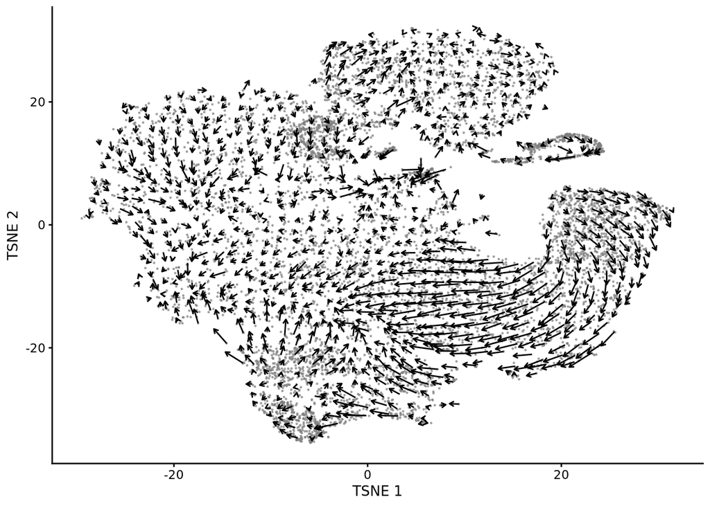

```r
plotReducedDim(sce, "TSNE",colour_by="if_progen_cluster", point_size=pt_size) +
    geom_segment(data=grid.df, mapping=aes(x=start.tsne_1, y=start.tsne_2,
        xend=end.tsne_1, yend=end.tsne_2, colour=NULL), width=1,arrow=arrow(length=unit(0.05, "inches"))) +
  scale_colour_manual(values=c(prog_cols,clusters))
```

## poking around the output object

```r
colnames(colData(velo.out))
```

```
## [1] "velocity_self_transition"       "root_cells"
## [3] "end_points"                     "velocity_pseudotime"
## [5] "latent_time"                    "velocity_length"
## [7] "velocity_confidence"            "velocity_confidence_transition"
```

```r
names(rowData(velo.out))
```

```
##  [1] "fit_r2"                "fit_alpha"             "fit_beta"
##  [4] "fit_gamma"             "fit_t_"                "fit_scaling"
##  [7] "fit_std_u"             "fit_std_s"             "fit_likelihood"
## [10] "fit_u0"                "fit_s0"                "fit_pval_steady"
## [13] "fit_steady_u"          "fit_steady_s"          "fit_variance"
## [16] "fit_alignment_scaling" "velocity_genes"        "varm"
```

I see a column here named root_cells. How does scvelo select root cells?  
velocity confidence, cool, but confidence_transition?

Then we have stuff calculated per gene; like alpha, beta & gamma; fit_steady, fit_likelihood

```r
summary(velo.out$root_cells)
```

```
##      Min.   1st Qu.    Median      Mean   3rd Qu.      Max.
## 0.0000000 0.0000689 0.0012242 0.0738165 0.0123001 1.0000000
```

```r
summary(velo.out$end_points)
```

```
##      Min.   1st Qu.    Median      Mean   3rd Qu.      Max.
## 0.0000000 0.0000281 0.0048970 0.1342003 0.1621539 1.0000000
```

```r
str(metadata(velo.out))
```

```
## List of 5
##  $ neighbors         :List of 4
##   ..$ connectivities_key: chr "connectivities"
##   ..$ distances_key     : chr "distances"
##   ..$ indices           : num [1:7710, 1:30] 0 1 2 3 4 5 6 7 8 9 ...
##   ..$ params            :List of 4
##   .. ..$ n_neighbors: int 30
##   .. ..$ method     : chr "umap"
##   .. ..$ metric     : chr "euclidean"
##   .. ..$ n_pcs      : NULL
##  $ recover_dynamics  :List of 2
##   ..$ fit_connected_states: logi TRUE
##   ..$ use_raw             : logi FALSE
##  $ velocity_params   :List of 5
##   ..$ fit_offset         : logi FALSE
##   ..$ mode               : chr "dynamical"
##   ..$ mode_neighbors     : chr "distances"
##   ..$ n_recurse_neighbors: int 2
##   ..$ perc               : int [1:2] 5 95
##  $ velocity_graph    :Formal class 'dgRMatrix' [package "Matrix"] with 6 slots
##   .. ..@ p       : int [1:7711] 0 108 286 394 463 537 562 616 680 739 ...
##   .. ..@ j       : int [1:1130306] 3 29 34 136 139 142 145 154 159 205 ...
##   .. ..@ Dim     : int [1:2] 7710 7710
##   .. ..@ Dimnames:List of 2
##   .. .. ..$ : NULL
##   .. .. ..$ : NULL
##   .. ..@ x       : num [1:1130306] 0.453 0.588 0.639 0.663 0.415 ...
##   .. ..@ factors : list()
##  $ velocity_graph_neg:Formal class 'dgRMatrix' [package "Matrix"] with 6 slots
##   .. ..@ p       : int [1:7711] 0 150 241 256 379 631 854 918 979 1064 ...
##   .. ..@ j       : int [1:984663] 9 16 48 49 60 127 131 132 137 140 ...
##   .. ..@ Dim     : int [1:2] 7710 7710
##   .. ..@ Dimnames:List of 2
##   .. .. ..$ : NULL
##   .. .. ..$ : NULL
##   .. ..@ x       : num [1:984663] -0.139 -0.1079 -0.3845 -0.0276 -0.5286 ...
##   .. ..@ factors : list()
```

## Velocity confidence and length

confidence = coherence of velocity directions  
length = speed of transcription between cells = roughly arrow length

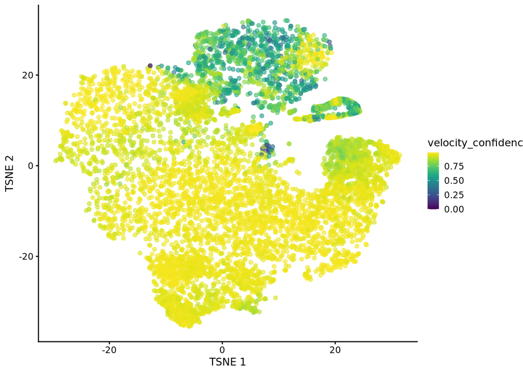

```r
sce$velocity_confidence = velo.out$velocity_confidence
sce$velocity_length = velo.out$velocity_length
plotReducedDim(sce, "TSNE",color_by="velocity_confidence", )
```

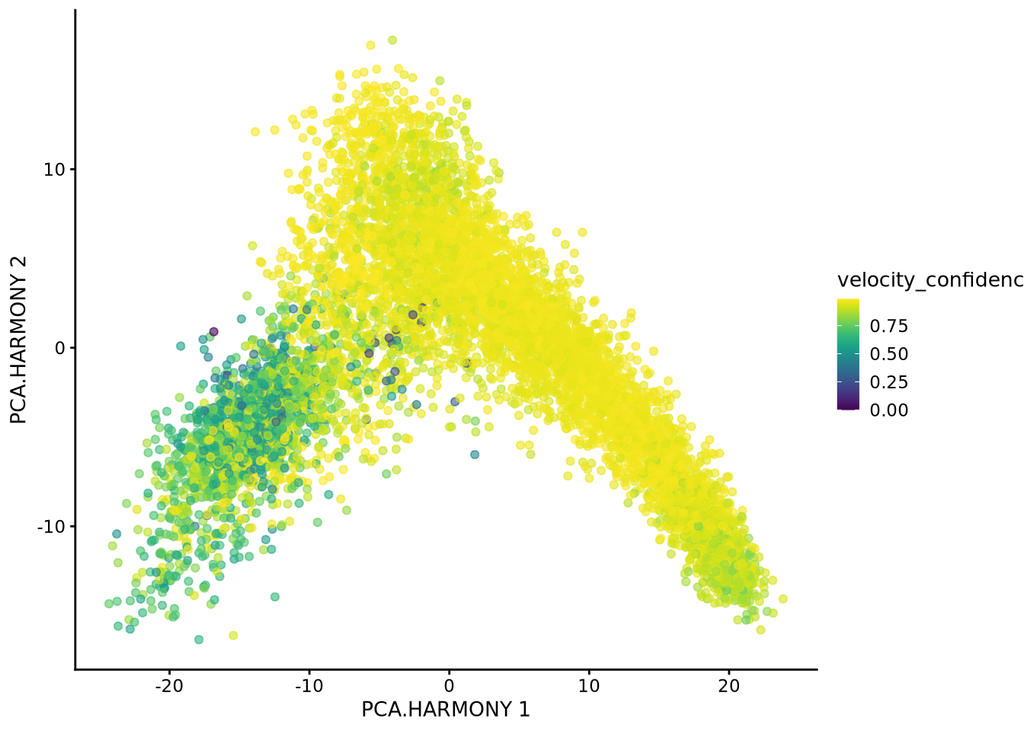

```r
plotReducedDim(sce, red_name,color_by="velocity_confidence", )
```

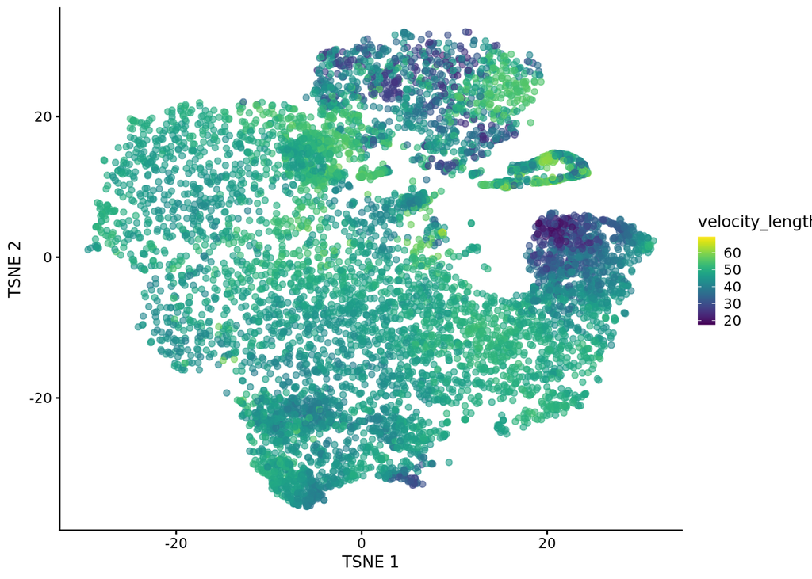

```r
plotReducedDim(sce, "TSNE",color_by="velocity_length" )
```

## Velocity stream plots

```r
colnames(reducedDim(sce, "TSNE"))
```

```
## [1] "tsne_1" "tsne_2"
```

```r
str(embedded)
```

```
##  num [1:7710, 1:2] 0.0819 -0.3084 -0.2566 0.2032 -0.0291 ...
```

```r
colnames(reducedDim(sce, "TSNE")) = c("V1","V2")
str(embedded)
```

```
##  num [1:7710, 1:2] 0.0819 -0.3084 -0.2566 0.2032 -0.0291 ...
```

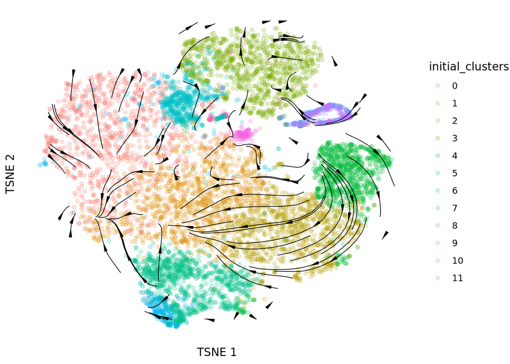

```r
plotVelocityStream(sce, embedded, use.dimred="TSNE",
                   color_by = "initial_clusters",grid.resolution=20,
                   stream.L = 10,
                   arrow.angle = 10, arrow.length = 0.5)
```

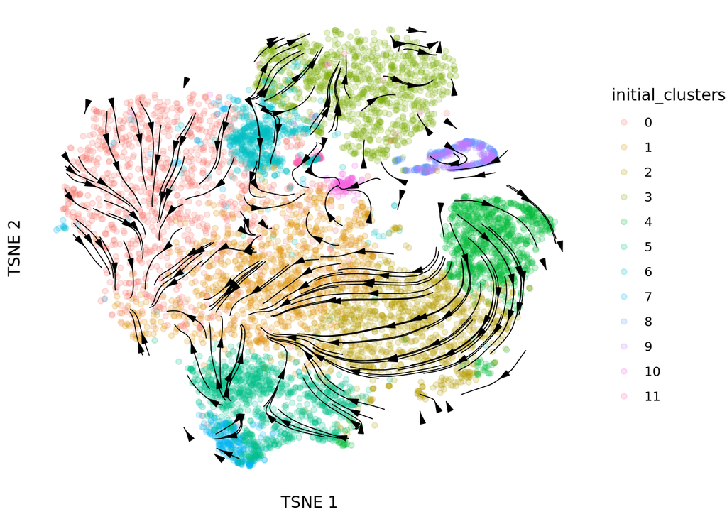

```r
plotVelocityStream(sce, embedded, use.dimred="TSNE",
                   color_by = "initial_clusters",grid.resolution=30,
                   stream.L = 8,
                   arrow.angle = 15, arrow.length = 0.5)
```

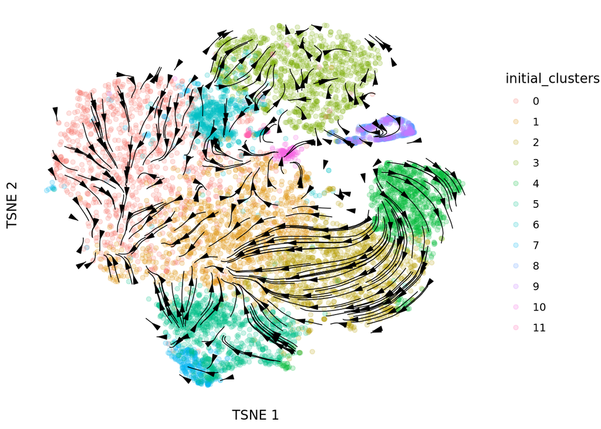

```r
plotVelocityStream(sce, embedded, use.dimred="TSNE",
                   color_by = "initial_clusters",grid.resolution=40,
                   stream.L = 5,
                   arrow.angle = 15, arrow.length = 0.5)
```

```r
if (subset_data == F){
  saveRDS(sce, file = here(odir, paste0(model, "_velocity_scexperiment_beige.rds")))
  saveRDS(velo.out, file = here(odir,paste0(model, "_velocity_output_beige.rds")))

} else if (subset_data){
  saveRDS(sce, file = here(odir, paste0("10%_subset_", model, "_velocity_scexperiment_beige.rds")))
  saveRDS(velo.out, file = here(odir, paste0("10%_subset_", model, "_velocity_output_beige.rds")))
}
```